# School Electricity Analysis

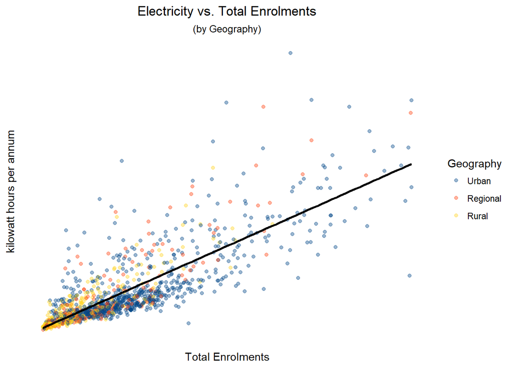

```r
# Plot: Electricity vs. Enrol (by Geography)
ggplot(tbl1617, aes(y = Elec, x = Enrol, colour = Geography)) +
  geom_point(alpha = 0.4) +
  geom_smooth(method = "lm", se = FALSE, colour = "black") +
  ggtitle("Electricity vs. Total Enrolments", subtitle = "(by Geography)") +
  xlab("Total Enrolments") +
  ylab("kilowatt hours per annum") +
  scale_colour_calc() +
  theme_minimal() +
  theme(plot.title = element_text(hjust = 0.5),
        plot.subtitle = element_text(hjust = .5))+
  # Hide numbers if showing plot publicly
  theme(axis.text = element_blank(),
        panel.grid = element_blank())
```

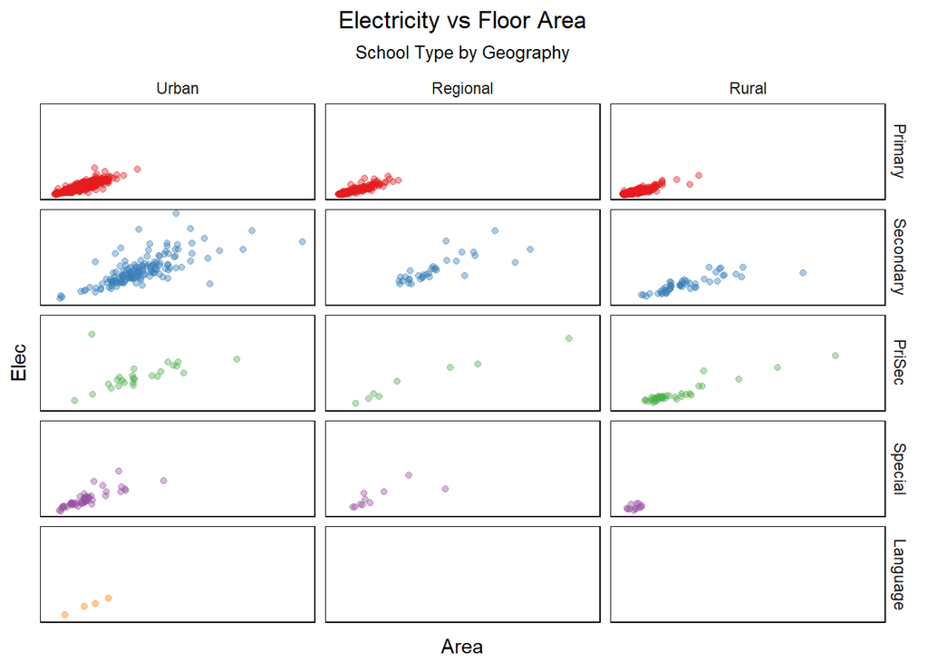

```r
# Plot:Electricity vs Area by Type:Geography - with Facets
ggplot(data = tbl1617, aes(x = Area, y = Elec, colour = Type)) +
  geom_point(alpha = 0.4) +
  facet_grid(Type ~ Geography) +
  ggtitle("Electricity vs Floor Area",
          subtitle = "School Type by Geography") +
  scale_color_brewer(palette = "Set1")+
  theme_minimal() +
  theme(plot.title = element_text(hjust = 0.5),
        plot.subtitle = element_text(hjust =  0.5),
        legend.position = "none")+
  # Hide numbers if showing plot publicly
  theme(axis.text = element_blank(),
        panel.grid = element_blank(),
        panel.border = element_rect(colour = "black",fill=0))
```

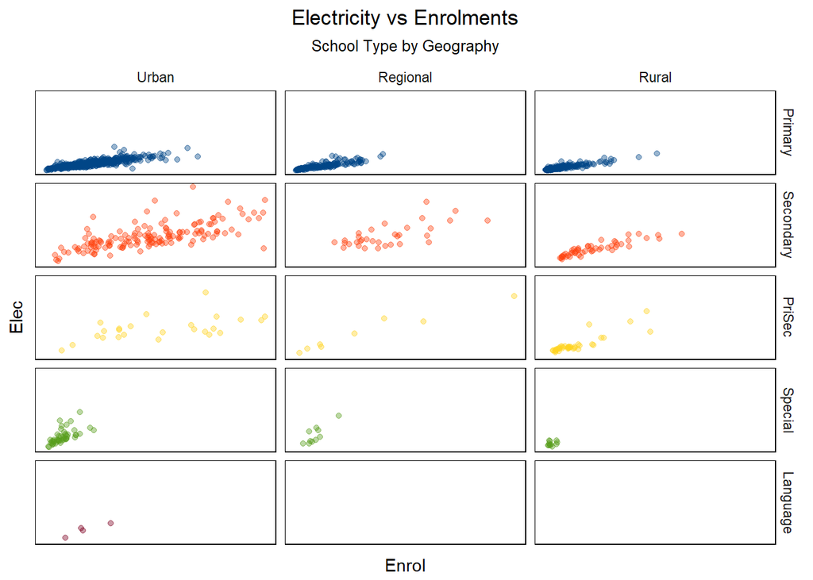

```r
# Plot: Electricity vs Enrol by Type:Geography - with Facets

ggplot(data = tbl1617, aes(x = Enrol, y = Elec, colour = Type)) +
  geom_point(alpha = 0.4) +
  facet_grid(Type ~ Geography) +
  ggtitle("Electricity vs Enrolments",
          subtitle = "School Type by Geography") +
  scale_colour_calc() +
  theme_minimal() +
   theme(plot.title = element_text(hjust = 0.5),
        plot.subtitle = element_text(hjust =  0.5),
        legend.position = "none")+
  # Hide numbers if showing plot publicly
  theme(axis.text = element_blank(),
        panel.grid = element_blank(),
        panel.border = element_rect(colour = "black",fill=0))
```

### Solar

#### Solar Summary Statistics: No Solar vs with Solar

```r
tbl1617%>%
  mutate(Solar = fct_recode(Solar, "NoSolar"="0","Solar"="1"))%>%
  tabyl(Type,Solar, show_missing_levels = F)%>%
  adorn_totals(where = c("row","col"))%>%
  adorn_percentages()%>%
  adorn_pct_formatting()%>%
  adorn_ns(position = "front")
```

#### Summary of Average kWh/m2: Solar vs No Solar

```r
tbl1617 %>%
  group_by(Solar) %>%
  summarise(Avg = round(mean(kWh_m2),2),
            Std = round(sd(kWh_m2),2))
```

#### Plot: Histogram of Average kWh/m2: Solar vs No Solar

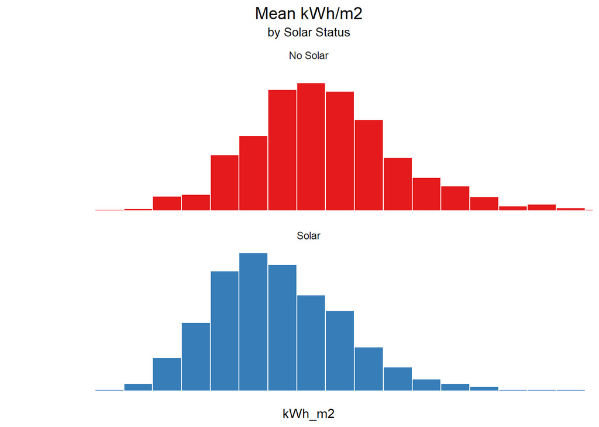

```r
Solarlabel <- as_labeller(c("0" = "No Solar", "1" = "Solar"))

ggplot(tbl1617) +
  geom_histogram(aes(x = kWh_m2, y = ..density.., fill = Solar),
                 binwidth = 2.8, colour = "white") +
  scale_x_continuous(breaks = seq(0,50,5)) +
  coord_cartesian(xlim = c(0,50)) +
  facet_wrap(~Solar, nrow = 2,
             labeller = Solarlabel) +
  scale_fill_brewer(palette = "Set1") +
  ggtitle("Mean kWh/m2", subtitle = "by Solar Status") +
  ylab("")+
  theme_minimal() +
  theme(
    plot.title = element_text(size = 14, hjust = 0.5),
    plot.subtitle = element_text(size = 10, hjust = 0.5),
    legend.position = 0,
    axis.text = element_blank())+
  # Hide numbersSolar if showing plot publicly
  theme(axis.text = element_blank(),
        panel.grid = element_blank())
```

#### Solar - Summary of Average kWh/Student: No Solar vs Solar

```r
# Summary of Average kWh/Student: Solar vs No Solar
tbl1617 %>%
  group_by(Solar) %>%
  summarise(Avg = round(mean(kWh_Enrol),2),
            Std = round(sd(kWh_Enrol),2))
```

#### Histogram of Average kWh/Student: Solar vs No Solar

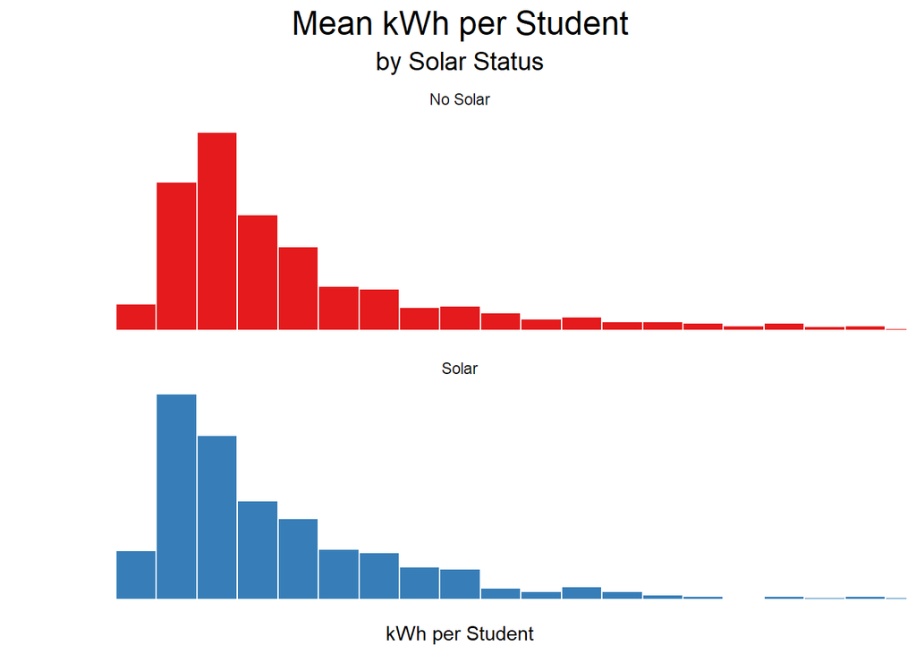

```r
ggplot(tbl1617, aes(x = kWh_Enrol, y = ..density.., fill = Solar)) +
  geom_histogram(binwidth = 75, colour = "white") +
  facet_wrap(~Solar, nrow = 2, labeller = Solarlabel) +
  scale_fill_brewer(palette = "Set1") +
  ylab(NULL) +
  xlab("kWh per Student") +
  coord_cartesian(xlim = c(0, 1500)) +
  ggtitle("Mean kWh per Student", subtitle = "by Solar Status") +
  theme_minimal() +
  theme(
    plot.title = element_text(hjust = 0.5, size = 18),
    plot.subtitle = element_text(hjust = 0.5, size  = 14),
    axis.title.y = element_blank(),
    axis.line.y = element_blank(),
    axis.text.y = element_blank(),
    legend.position = 0) +
  # Hide numbersSolar if showing plot publicly
  theme(axis.text = element_blank(),
        panel.grid = element_blank())
```

#### Solar - Summary of Average kWh/m2: No Solar vs Solar, by School Type

```r
tbl1617 %>%
  group_by(Type, Solar) %>%
  summarise(avg = round(mean(kWh_m2),2)) %>%
  spread(Solar, avg)
```

#### Density Plots: Consumption per Square Metre: No Solar vs Solar, by School Type

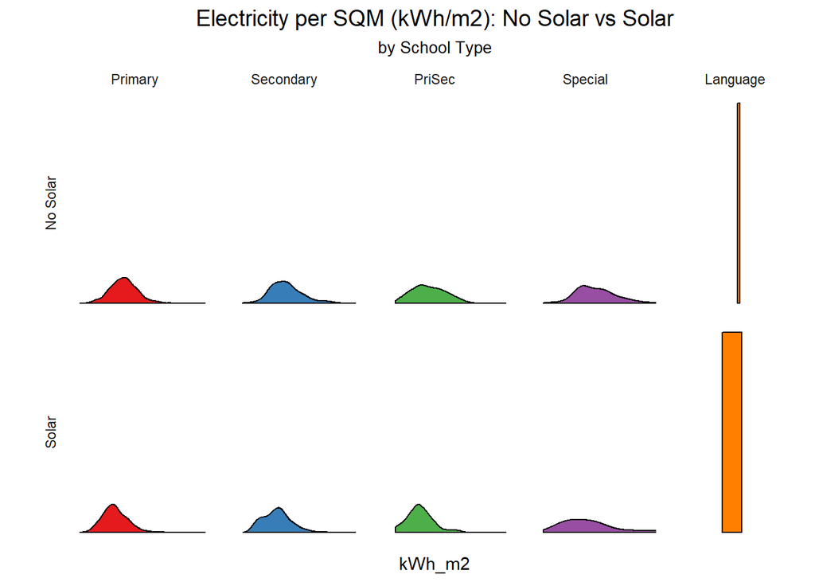

```r
ggplot(tbl1617) +
  geom_density(aes(x = kWh_m2, fill = Type)) +
  facet_grid(Solar ~ Type ,scales = "free",
             labeller = labeller(Solar = Solarlabel),
             switch = "y") +
  coord_cartesian(xlim = c(0,60)) +
  ylab("") +
  ggtitle("Electricity per SQM (kWh/m2): No Solar vs Solar", subtitle = "by School Type") +
  theme_minimal() +
  scale_fill_brewer(palette = "Set1") +
  theme(legend.position = 0,
        axis.text.y = element_blank(),
        plot.title = element_text(size = 14, hjust = 0.5),
        plot.subtitle = element_text(size = 10, hjust = 0.5))+
  # Hide numbersSolar if showing plot publicly
  theme(axis.text = element_blank(),
        panel.grid = element_blank())
```

End of exploratory analysis; prepare for model building. Due to very small numbers exclude Language schools from the tibble to be used for model creation:

```r
# Small Sample of Language Schools, remove from analysis
tblExLang <- tbl1617 %>%
   filter(Type != "Language") %>%
   mutate(Area.c = Area - mean(Area)) # Mean-centre Area

tblExLang <- droplevels(tblExLang) # drop Language schools from dataframe
```

# Model Creation

*(Added 23 Sep 2018)*

## Model Type: Ordinary Least Squares

**Model Building Methodology:** Backwards Elimination Starting From Original Full Model a0:

$$Elec = {\beta_0}~+{\beta_1}Area~+{\beta_2}Enrol~+{\beta_3}Type~+{\beta_4}Geography~+{\beta_5BCAZone}~+{\beta_6}Solar~+{\epsilon},$$

where *BCAZone* is the Building Code of Australia Climate Zone, and $\epsilon$ is the disturbance (or error) term representing other factors affecting electricity consumption.

**Process:** order of variable elimination based on:

- smallest impact observed from prior analyses; and/or
- smallest level of statistical significance in existing model.

Final decision on whether to accept or reject variable elimination based on a combination of:

- statistical indicators e.g. AIC and BIC, root mean square error (RMSE), adjusted R<sup>2</sup>, Ramsey RESET etc; and
- information that would reasonably be sought when wanting to understand the factors impacting on school electricity consumption.

Note that the explanatory variables chosen are the ones that were seen in prior exploratory analysis to have a significant impact on electricity consumption. Explanatory variables excluded are those that are either not relevant (e.g. cost) or were seen to have no sigficant impact in prior analysis.

### Create Root Mean Square Error (RMSE) function

```r
rmse <- function(x){
  sqrt(mean(x$residuals^2))
}
```

As the square root of a variance, RMSE can be interpreted as the standard deviation of the unexplained variance, and has the useful property of being in the same units as the response variable. Lower values of RMSE indicate better fit. RMSE is a good measure of how accurately the model predicts the response.

### Original Full Model:

```r
a0 <- lm(Elec~Area + Enrol + Type + Geography + BCA + Solar, data=tblExLang)
summ(a0,robust = T, center = T, vifs=T)
rmse(a0)
```

### ‘a-Set’ Models: Removal of Variables

#### Removing One Variable

```r
a1.1 <- lm(Elec~Area + Enrol + Solar + Type + Geography, data=tblExLang)
summ(a1.1,center = T, robust = T, vifs=T)

a1.2 <- lm(Elec~Area + Enrol + Solar + Type + BCA, data=tblExLang)
summ(a1.2,center = T, robust = T, vifs=T)

a1.3 <- lm(Elec~Area + Solar + Type + Geography + BCA, data=tblExLang)
summ(a1.3,center = T, robust = T, vifs=T)

a1.4 <- lm(Elec~Enrol + Solar + Type + Geography + BCA, data=tblExLang)
summ(a1.4,center = T, robust = T, vifs=T)

# Group models
a1.models <- list(a0, a1.1, a1.2, a1.3, a1.4)

# Find RMSE
sapply(a1.models,rmse)

# Use Akaike Information Criteria and Bayesian information criterion
sapply(a1.models, AIC) # AIC values
sapply(a1.models, BIC) # BIC values
```

AIC and BIC both prefer model a1.1, which excludes Building Code of Australia (BCA) Climate Zone. However it would be reasonable to expect for a model (or other research) of electricity consumption to explore the impact of climate. The other variables are also expected to be of business interest. However, Area and Enrol are strongly correlated (r<sup>2</sup>=0.82), therefore likely to be high multicollinearity (indicated by VIFs). If one of these variables were to be eliminated, then it would be Enrol, since Area has a stronger linear correlation with total Electricity consumption (r<sup>2</sup> = 0.90) than Enrol (r<sup>2</sup> = 0.82). Also prefer a1.3 over a1.4 going by Adj. R<sup>2</sup> and AIC/BIC. So model of choice is a1.3 over a0.

#### Eliminate Two Variables (including Enrol)

```r
# Eliminate BCA
a2.1 <- lm(Elec~Area+Type+Solar+Geography,data=tblExLang)
summ(a2.1,center = T,robust = T,vifs = T)

# Compare RMSE with a1.3
sapply(list(a1.3, a2.1),rmse)

# Compare AIC and BIC
sapply(list(a1.3, a2.1),AIC)
sapply(list(a1.3, a2.1),BIC)
```

In terms of overall predictive ability and parsimony, a2.1 is preferred over a1.3 (note: a2.1 is nested within a1.3).

#### Eliminate Geography

```r
a3.1 <- lm(Elec~Area+Type+Solar,data=tblExLang)
summ(a3.1,center = T,robust = T,vifs = T)
rmse(a3.1)
# Compare a3.1, a2.1, and a1.3:
# (Note: all three have Adj. R² = 0.84)
AIC(a3.1, a2.1, a1.3)
BIC(a3.1, a2.1, a1.3)
```

Model 3.1 has the highest AIC/BIC score, while a2.1 has lowest AIC/BIC score. This indicates further variable elimination would lead to further information loss. It also implies that Geography is important for predictive performance and that Climate Zone (at least in terms of separately comparing Zone 4 and Zone 7 with Zone 6) adds no further explanatory power to a model of this simple functional form.

Thus out of these ‘a-Set’ models, model a2.1 is the most preferred i.e. lm(Elec~Area+Type+Solar+Geography,data=tblExLang).

#### Test of Model Assumptions

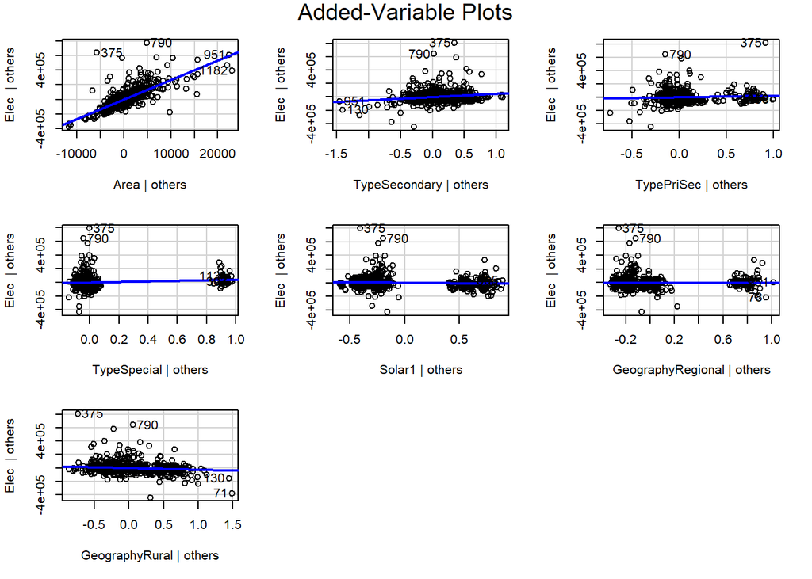

```r
avPlots(a2.1)
```

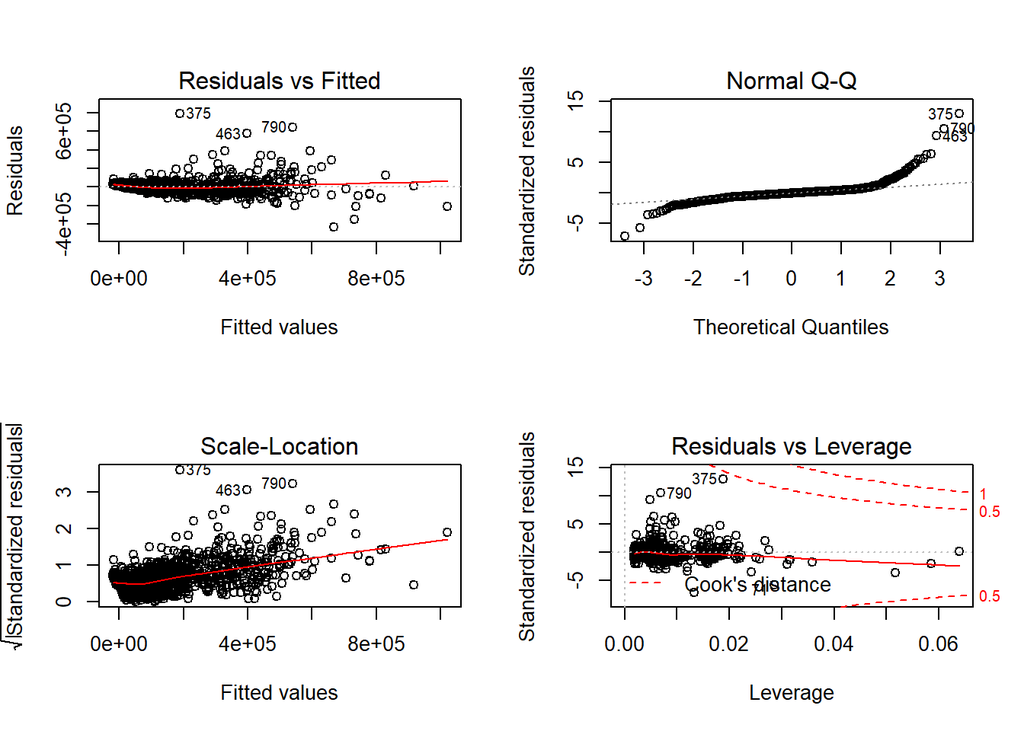

```r
# The plot Elec|other vs Area|others shows linearity

par(mfrow = c(2,2))
plot(a2.1)
```

Plot shows evidence of heteroscedaticity as given by the Residuals vs Fitted and Standardised Residuals vs Fitted plots. This implies less efficient OLS estimators (i.e a larger sample size is required for OLS estimators to converge to the true value). It also means the variance of the OLS estimators may be both biased an inconsistent. In practice it means that the variance, and therefore standard errors of the estimators are substantially underestimated. This implies a need for heteroscedasticity-consistent standard errors.

The Residuals vs Leverage plot shows a number of high leverage observations. However, there is insuffficient evidence they have any undue influence on the model (as given by Cook’s distance lines).

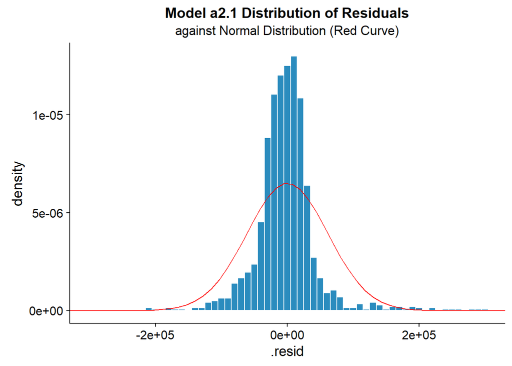

```r
augment(a2.1)%>%
  ggplot(aes(x=.resid)) +
  geom_histogram(aes(y=..density..),
                 binwidth = 10000,
                 colour="white", fill="#2b8cbe") +
  stat_function(fun = dnorm,
                args = list(mean=mean(augment(a2.1)$.resid,na.rm=TRUE),
                            sd=sd(augment(a2.1)$.resid,na.rm=TRUE)),
                col="red") +
  labs(title="Model a2.1 Distribution of Residuals",
       subtitle="against Normal Distribution (Red Curve)")+
  coord_cartesian(xlim = c(-3e+5,3e+5))+
  theme(plot.subtitle = element_text(hjust=0.5),
        plot.caption = element_text(hjust=0.5))
```

While the distribution of residuals is leptokurtic (thin-tailed) it seems to be ‘normal enough’ to assume Normality assumption is met.

**Note:** Model a2.1 with robust std errors and centred continuous predictor Area:

```r
a2.1r <- lm_robust(Elec~Area.c+Type+Solar+Geography,data=tblExLang,
                   se_type = "HC3")

summary(a2.1r)
```

#### Testing of Functional Form: Ramsey RESET test

##### Using reset() function

```r
reset(a2.1)
```

```
##
##  RESET test
##
## data:  a2.1
## RESET = 49.034, df1 = 2, df2 = 1429, p-value < 2.2e-16
```

```r
# Reject H~0~ that there is no model misspecification
# i.e conclude model is misspecified
```

#### Manual Calculation Using Wald Test with F-Distribution

```r
# 1) Tidy the lm object
a2.1_tidy <- augment(a2.1)
# head(a2.1_tidy)

# 2) Create nested model with y-hat^2 and y-hat^3
a2.1nst <- lm(Elec~Area+Type+Solar+Geography+I(.fitted^2)+I(.fitted^3),
              data=a2.1_tidy)

# 3) Perform waldtest
# This tests the following Hypothesis: I(.fitted^2) = 0 and I(.fitted^3 = 0)
# Set test = "F" to compute F-statistic with F-distribution

waldtest(a2.1nst,a2.1)
```

```
## Wald test
##
## Model 1: Elec ~ Area + Type + Solar + Geography + I(.fitted^2) + I(.fitted^3)
## Model 2: Elec ~ Area + Type + Solar + Geography
##   Res.Df Df      F    Pr(>F)
## 1   1429
## 2   1431 -2 49.034 < 2.2e-16 ***
## ---
## Signif. codes:  0 '***' 0.001 '**' 0.01 '*' 0.05 '.' 0.1 ' ' 1
```

```r
waldtest(a2.1nst,a2.1, test="F")
```

```
## Wald test
##
## Model 1: Elec ~ Area + Type + Solar + Geography + I(.fitted^2) + I(.fitted^3)
## Model 2: Elec ~ Area + Type + Solar + Geography
##   Res.Df Df      F    Pr(>F)
## 1   1429
## 2   1431 -2 49.034 < 2.2e-16 ***
## ---
## Signif. codes:  0 '***' 0.001 '**' 0.01 '*' 0.05 '.' 0.1 ' ' 1
```

Reject H<sub>0</sub> that there is no model misspecification i.e conclude model is misspecified.

#### RESET Test - with Heteroskedasticity-Robust F statistic

**(Also called heteroskedasticity-robust Wald statistic)**

Use the vcov = vcovHC argument to estimate a Heteroskedasticity-Consistent covariance matrix.

```r
reset(a2.1,vcov = vcovHC)
```

```
##
##  RESET test
##
## data:  a2.1
## RESET = 13.955, df1 = 2, df2 = 1431, p-value = 9.95e-07
```

```r
waldtest(a2.1nst,a2.1,vcov = vcovHC)
```

```
## Wald test
##
## Model 1: Elec ~ Area + Type + Solar + Geography + I(.fitted^2) + I(.fitted^3)
## Model 2: Elec ~ Area + Type + Solar + Geography
##   Res.Df Df      F   Pr(>F)
## 1   1429
## 2   1431 -2 13.955 9.95e-07 ***
## ---
## Signif. codes:  0 '***' 0.001 '**' 0.01 '*' 0.05 '.' 0.1 ' ' 1
```

Even with Heteroskedasticity-Consistent covariance matrix still reject H<sub>0</sub>. Therefore conclude model is still misspecified.

### ‘b-Set’ Models: Involves interaction between Area and (School) Type

Prior analysis has shown interaction between floor area and school type with respect to electricity consumption:

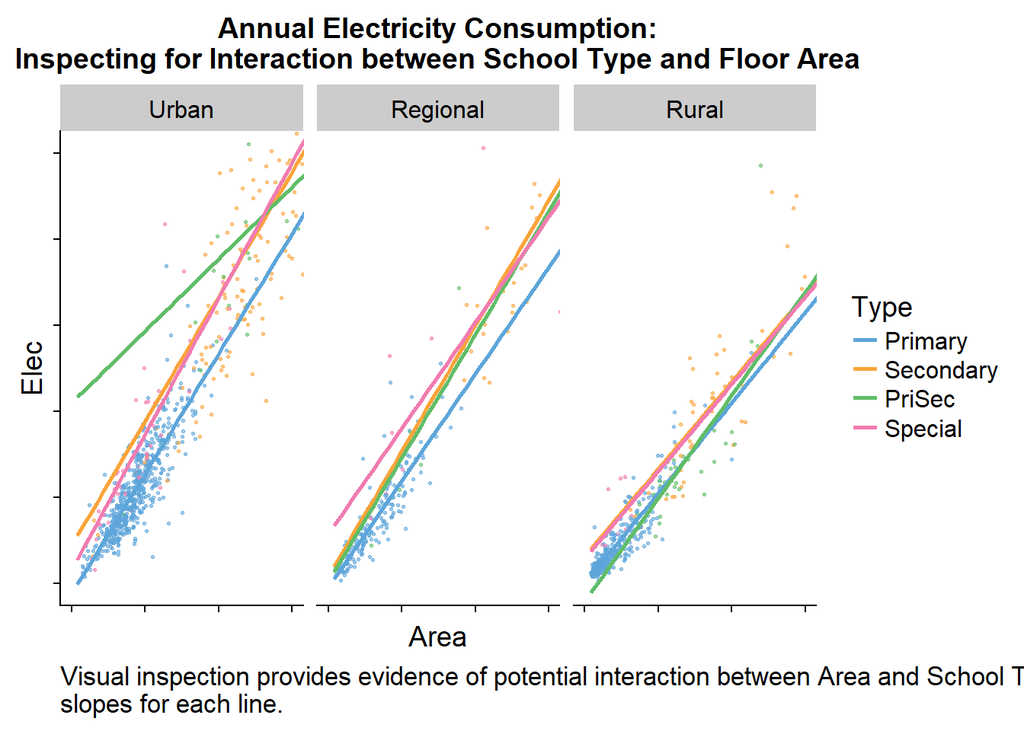

```r
tblExLang%>%
  ggplot(aes(x=Area,y=Elec,colour=Type))+
  geom_point(size=0.6, alpha=0.6)+
  geom_smooth(method="lm", se=F,fullrange=T)+
  scale_color_few()+
  coord_cartesian(xlim=c(0,15000),ylim=c(0,500000))+
 facet_wrap(~Geography)+
  labs(title="Annual Electricity Consumption:\nInspecting for Interaction between School Type and Floor Area",
       caption="Visual inspection provides evidence of potential interaction between Area and School Type, as shown by the differing\nslopes for each line.")+
  theme(plot.caption=element_text(hjust=0)) +
  # remove figures if showing publicly
  theme(axis.text=element_blank())
```

#### Interaction Term, with BCA in Model:

```r
b1.1 <- lm(Elec~Area.c*Type+Solar+Geography+BCA,data=tblExLang)
summ(b1.1,robust=T,vifs=T)
rmse(b1.1)
```

#### Interaction Term, without BCA:

```r
# Without BCA:
b1.2 <- lm(Elec~Area.c*Type+Solar+Geography,data=tblExLang)
summ(b1.2, robust=T, vifs=T)
rmse(b1.2)
```

#### Testing AIC and BIC

```r
AIC(b1.1, b1.2)
```

```
##      df      AIC
## b1.1 14 35810.87
## b1.2 12 35811.74
```

```r
BIC(b1.1, b1.2)
```

```
##      df      BIC
## b1.1 14 35884.67
## b1.2 12 35875.00
```

Given these AIC/BIC results,the fact that both models have an adj. R² of 0.84, it seems that BCA is superfluous and therefore can be removed. Nonetheless it is reasonable to want to know what effect climate zone has on energy use so there’s also an argument for leaving in BCA.

However note the very high vifs for Area, Type, and (especially) the Area:Type interactions. This might indicate potential multicollinearity problems for these variables, although further investigation is required to see if an issue actually exists. If multicollinearity is severe enough it can significantly increase the variance (and therefore standard errors) of the coefficient estimates and make the estimates very sensitive to minor changes in the model. The result is that the coefficient estimates are unstable and difficult to interpret. Seeing if there multicollinearity is causing a problem in the model can be performed with techniques like ridge regression.

#### Test of Functional Form - Ramsey RESET Test (b-set models)

**Using Heteroskedasticity-Robust F statistic**

```r
reset(b1.1, vcov = vcovHC)
```

```
##
##  RESET test
##
## data:  b1.1
## RESET = 3.1705, df1 = 2, df2 = 1426, p-value = 0.04228
```

```r
reset(b1.2, vcov = vcovHC)
```

```
##
##  RESET test
##
## data:  b1.2
## RESET = 2.8527, df1 = 2, df2 = 1428, p-value = 0.05802
```

Based on this result model b1.2 deemed to have a correct functional form, but not much more so than b1.1. However b1.1 seems to have slightly better predictive ability than b1.2 as given by root mean square error. For the sake of choosing just one model b1.2 (without BCA) is preferred over b1.1 (with BCA).

### Model Creation: “c-Set” - Interaction between Geography and BCA

Previous analysis of geography and climate zone concluded that assessing the effects of climate needs to be performed at a level that takes into account local variations. This conclusion was supported by an interaction between BCA Zone and Geography.

```r
c1.1 <- lm(Elec~Area+Type+Solar+Geography*BCA,data=tblExLang)
summ(c1.1, robust=T, center=T, vifs=F)
```

Note the error message regarding aliased coefficients, and the NAs for the GeographyRural:BCAZone_4 interaction.

Further investigation shows linear dependence on BCAZone_4 and GeographyRegional:BCAZone_4.

```r
alias(c1.1)
```

```
## Model :
## Elec ~ Area + Type + Solar + Geography * BCA
##
## Complete :
##                          (Intercept) Area TypeSecondary TypePriSec
## GeographyRural:BCAZone_4  0           0    0             0
##                          TypeSpecial Solar1 GeographyRegional
## GeographyRural:BCAZone_4  0           0      0
##                          GeographyRural BCAZone_4 BCAZone_7
## GeographyRural:BCAZone_4  0              1         0
##                          GeographyRegional:BCAZone_4
## GeographyRural:BCAZone_4 -1
##                          GeographyRegional:BCAZone_7
## GeographyRural:BCAZone_4  0
##                          GeographyRural:BCAZone_7
## GeographyRural:BCAZone_4  0
```

This is not surprising since there are no Urban/metropolitan schools in Climate Zone 4. The coefficient for BCAZone_4, which is practically zero, is also evidence of this. This has resulted in ‘singularity’ or perfect multicollinearity, which led to unstable results.

Try creating a new Climate Zone variable with different coding of levels:

```r
# Create new variable using data from existing BCA variable:
tblExLang$Zones4Or7 <- tblExLang$BCA
# Recode variables such that the reference level is *not* Zone 4 or Zone 7
levels(tblExLang$Zones4Or7) <- list("0" = "Zone_6", "1" = c("Zone_4","Zone_7"))

# Create new model
c1.2 <- lm(Elec~Area+Type+Solar+Geography*Zones4Or7,data=tblExLang)
summ(c1.2, center=T, robust=T, vifs=T)
```

Here we’ve combined Zones 4 and 7 into one level (to represent *not* Zone 6), and this has resolved the singularity issue.

#### Test of Functional Form - Ramsey RESET Test

```r
reset(c1.2, vcov=vcovHC)
```

```
##
##  RESET test
##
## data:  c1.2
## RESET = 17.566, df1 = 2, df2 = 1428, p-value = 2.91e-08
```

Model c1.2 seems to be impacted by misspecification.

### Model Creation: “d-Set” - Create Model with Area:Type and Geography:BCA Interactions

```r
d1.1 <- lm(Elec~Area*Type+Solar+Geography*Zones4Or7,data=tblExLang)
summ(d1.1, robust=T, center=T, vifs=T)
```

#### Ramsey RESET

```r
reset(d1.1, vcov=vcovHC)
```

```
##
##  RESET test
##
## data:  d1.1
## RESET = 4.0897, df1 = 2, df2 = 1425, p-value = 0.01694
```

Reject H<sub>0</sub> no model misspecification. Current preferred model still b1.2.

### Model Creation: “e-Set” - Create model with Area:Type interaction and include Zone4or7

```r
e1.1 <- lm(Elec~Area*Type+Solar+Geography+Zones4Or7,data=tblExLang)
summ(e1.1, robust=T,center=T,vifs=T)
```

#### Test of Functional Form - Ramsey RESET

```r
reset(e1.1,vcov=vcovHC)
```

```
##
##  RESET test
##
## data:  e1.1
## RESET = 3.1736, df1 = 2, df2 = 1427, p-value = 0.04215
```

Reject H<sub>0</sub> of no misspecification (Model b1.2 still our preferred model)

### Model Creation: “f-Set” - Create Model with Area:Type and Area:Solar Interactions

#### Create model with 3-way interaction (f1.1)

```r
f1.1 <- lm(Elec~Area.c*Type*Solar+Geography, data=tblExLang)
summ(f1.1, robust=T, vifs=T)
```

Insufficient evidence of a three-way interaction, and therefore cannot justify building such a (complex) model. Note that non-signficance of t-values may be due to high multicollinearity (as presented by vif figures).

#### Interactions between Area:Type and Area:Solar

Prior analysis has found an interaction between Solar and Area so incorporate here.

```r
f2.1 <- lm(Elec~Area.c*(Type+Solar)+Geography, data=tblExLang)
summ(f2.1,robust = T, vifs=T)
# Alternative version of f2.1
# f2.1.1 <- lm_robust(Elec~Area.c*(Type+Solar)+Geography, data=tblExLang,
#                     se_type = "HC3")
```

Area and Solar interaction meets the default criterion for statistically significant coefficients (p<0.05). Furthermore prior exploratory analysis has found an interaction between Solar use and floor area, and conceptually it makes sense for this relationship to be present (i.e. having solar lowers kWh/m2 consumption).So keep this interaction, and assess model further.

#### Test of Functional Form - Ramsey RESET Test (f2.1)

```r
reset(f2.1, vcov = vcovHC)
```

```
##
##  RESET test
##
## data:  f2.1
## RESET = 2.9101, df1 = 2, df2 = 1427, p-value = 0.05479
```

Cannot reject H<sub>0</sub> of no misspecification (at p = 0.05)

#### Compare Model f2.1 and Model b1.2

```r
# Akaike and Bayesian-Schwartz Information Criteria
AIC(f2.1, b1.2)
```

```
##      df      AIC
## f2.1 13 35786.28
## b1.2 12 35811.74
```

```r
BIC(f2.1, b1.2)
```

```
##      df      BIC
## f2.1 13 35854.81
## b1.2 12 35875.00
```

```r
# Root Mean Square Error
sapply(list(f2.1, b1.2), rmse)
```

```
## [1] 60261.84 60839.62
```

Both AIC and BIC favour model f2.1. Also f2.1 has Adj R<sup>2</sup> = 0.85, which is slightly higher than for b1.2 (Adj R<sup>2</sup> = 0.84), but also has lower root mean square error.

So model f2.1 is preferred over b1.2.

##### Testing Model Assumptions for Model f2.1

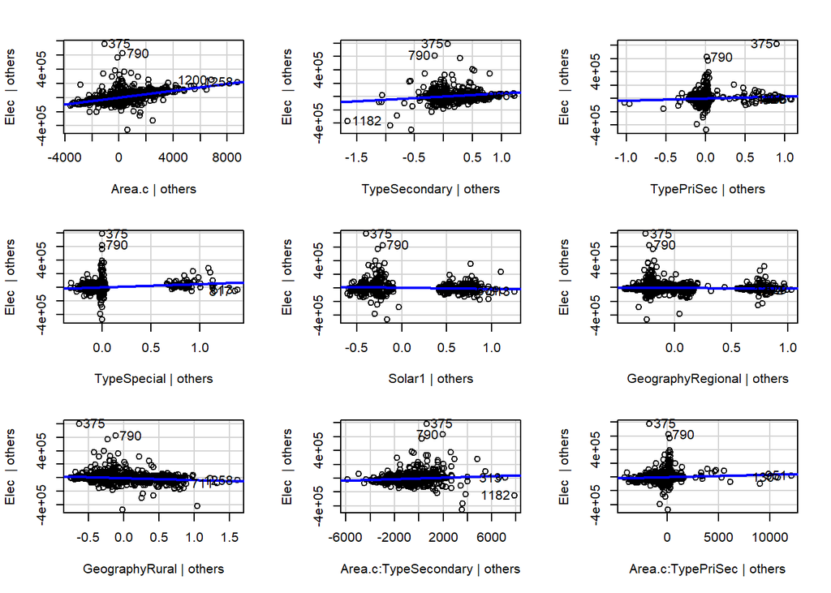

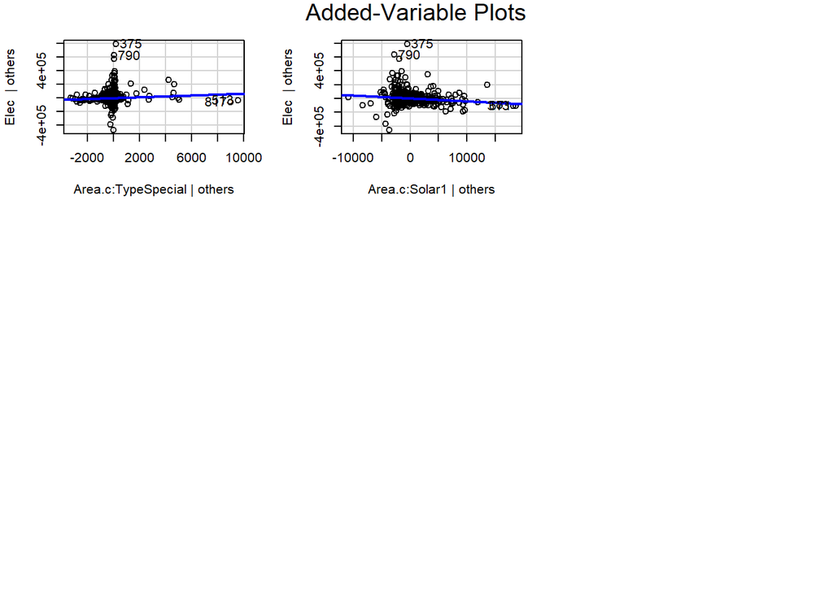

```r
avPlots(f2.1)
```

The plot ‘Elec|others vs Area.c|others’ shows linearity

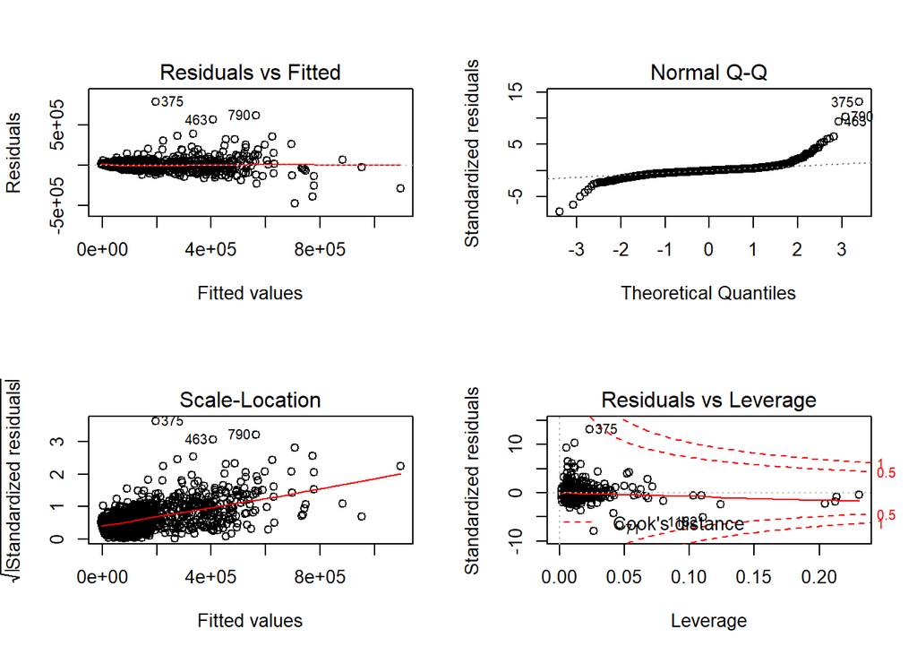

```r
par(mfrow = c(2,2))
plot(f2.1)
```

Plot shows evidence of heteroscedaticity as given by the Residuals vs Fitted and Standardised Residuals vs Fitted plots. This implies less efficient OLS estimators (i.e a larger sample size is required for OLS estimators to converge to the true value). It also means the variance of the OLS estimators may be both biased an inconsistent. In practice it means that the variance, and therefore standard errors of the estimators are substantially underestimated. This implies a need for heteroscedasticity-consistent standard errors.

The Residuals vs Leverage plot shows a number of high leverage observations. However,there is insuffficient evidence they have any undue influence on the model (as given by Cook’s distance lines).

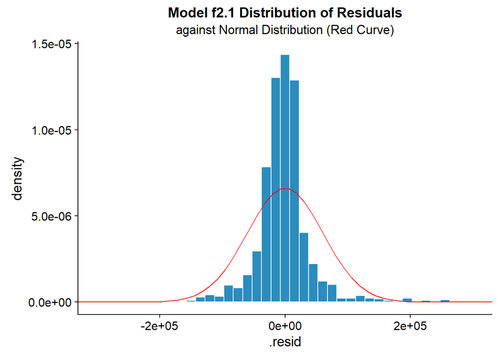

```r
augment(f2.1)%>%
  ggplot(aes(x=.resid)) +
  geom_histogram(aes(y=..density..),
                 binwidth = 15000,
                 colour="white", fill="#2b8cbe") +
  stat_function(fun = dnorm,
                args = list(mean=mean(augment(f2.1)$.resid,na.rm=TRUE),
                            sd=sd(augment(f2.1)$.resid,na.rm=TRUE)),
                col="red") +
  labs(title="Model f2.1 Distribution of Residuals",
       subtitle="against Normal Distribution (Red Curve)")+
  coord_cartesian(xlim = c(-3e+5,3e+5))+
  theme(plot.subtitle = element_text(hjust=0.5),
        plot.caption = element_text(hjust=0.5))
```

The distribution is leptokurtic (thin-tailed) but it seems to be ‘normal enough’ to assume Normality assumption is met.

#### Chosen Default Model

Given the above statistical diagnostic indicator for model f2.1, we will choose this as the default to further model school electricity consumption. The Chosen Default Model can thus be summarised as the following linear function:

$$Elec = {\beta_0}~+{\beta_1}Area_c~+{\beta_2}Type~+{\beta_3}Solar~+{\beta_4}Geography~+{\beta_5}Area_c.Type~+{\beta_6}Area_c.Solar~+{\epsilon},$$

where *Area<sub>c</sub>* is mean-centred floor area, and $\beta_0$ is the expected electricity consumption of a school with an average-sized floor area.

Note that floor area is mean-centred to ensure measurement against the average-sized school floor area, which will help with model interpretation. Furthermore, the base group is urban primary schools that do not use solar PV. This is the benchmark group against which all other comparisons are made.

#### Create Alternative Model f3.1: *Elec ~ f(Area, Type, Solar)*

Model f3.1 is a simplified variation of f2.1 where we are only interested in three variables, School Type, Area, and Solar PV usage:

$$Elec = {\beta_0}~+{\beta_1}Area_c~+{\beta_2}Type~+{\beta_3}Solar~+{\beta_4}Area_c.Type~+{\beta_5}Area_c.Solar~+{\epsilon}$$

Here we want to simplify assessments without having to consider other intricacies like whether schools are in urban, regional, or rural localities. The aim is to be able to make general statements about electricity consumption with respect to variables of greatest business interest.

```r
f3.1 <- lm(Elec~Area.c*(Type+Solar), data=tblExLang)
summ(f3.1,robust = T, vifs=T)
```

Area.c:Type interaction not statistically significant.This may be due to high multicollinearity between interacting terms and the main effects). Or it may be due to removing Geography as a factor Area.c:Solar interaction still statistically signficant.

##### Ramsey RESET test (heteroscedasticity-robust)

```r
reset(f3.1, vcov=vcovHC)
```

```
##
##  RESET test
##
## data:  f3.1
## RESET = 7.2839, df1 = 2, df2 = 1429, p-value = 0.0007123
```

Result: this rejects H<sub>0</sub> of no model misspecification, i.e. test rejects that this is a correctly specified linear model. In other words there are non-linear combinations of the fitted values that help explain the response variable (Electricity consumption).

In this case, we’ll explicitly declare that we are working with explicit approximations of a ‘true’ model, but argue that we can still derive defensible analyses and insights. We can do this by invoking the work of Berk et. al (2017): [Berk, R., Brown, L., Buja, A. et al. J Quant Criminol (2017)](https://doi.org/10.1007/s10940-017-9348-7)

##### Testing Model Assumptions for Model f3.1

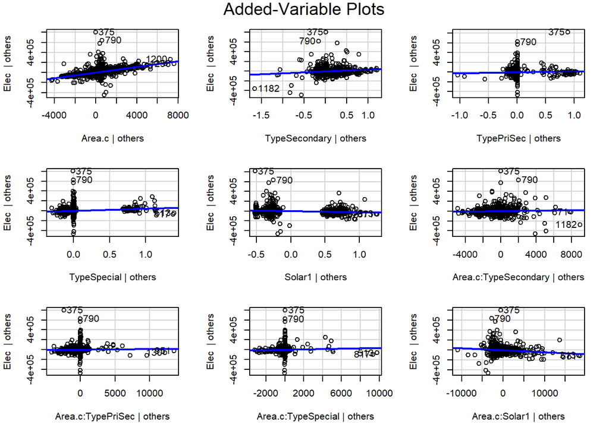

```r
avPlots(f3.1)
```

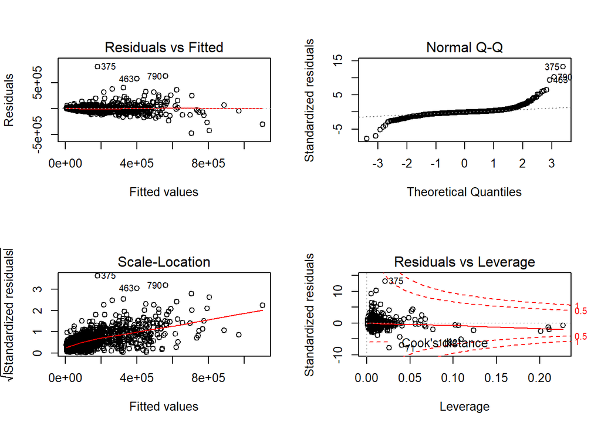

```r
# The plot Elec|others vs Area.c|others shows linearity


par(mfrow=c(2,2))
plot(f3.1)
```

```r
# Same conclusions as per previous models.
```

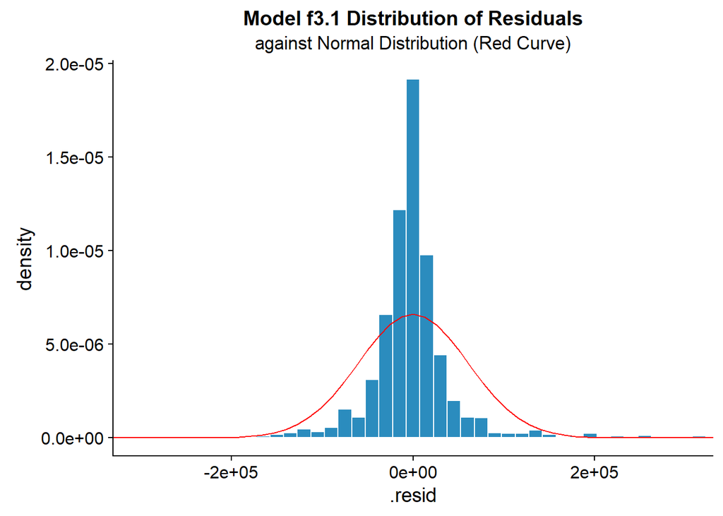

```r
augment(f3.1)%>%
  ggplot(aes(x=.resid)) +
  geom_histogram(aes(y=..density..),
                 binwidth = 15000,
                 colour="white", fill="#2b8cbe") +
  stat_function(fun = dnorm,
                args = list(mean=mean(augment(f2.1)$.resid,na.rm=TRUE),
                            sd=sd(augment(f2.1)$.resid,na.rm=TRUE)),
                col="red") +
  labs(title="Model f3.1 Distribution of Residuals",
       subtitle="against Normal Distribution (Red Curve)")+
  coord_cartesian(xlim = c(-3e+5,3e+5))+
  theme(plot.subtitle = element_text(hjust=0.5),
        plot.caption = element_text(hjust=0.5))
```

Distribution seems to be ‘normal enough’ to assume Normality assumption is met.

##### lm_robust version of f3.1:

```r
f3.1.1 <- lm_robust(Elec~Area.c*(Type+Solar), data=tblExLang,
                    se_type = "HC3")


#summary(f3.1.1)
```

#### Calculate Predicted Values based on Model f3.1.1: SET #1

**Assumptions:** * Floor area for each School Type is the estimated mean portfolio area (i.e x,xxx m2); and * Geography not taken into account.

**Create data separate dataframe** where the (mean-centred) floor area for the entire portfolio is assumed to be the same across all school types:

```r
df.1 <- data.frame(Area = rep(mean(tblExLang$Area)),
                   Area.c = rep(mean(tblExLang$Area.c)),
                   Type = factor(c(rep("Primary",2),
                                   rep("Secondary",2),
                                   rep("PriSec",2),
                                   rep("Special",2)),
                                 levels=c("Primary","Secondary","PriSec","Special")),
                   Solar = factor(rep(c("0","1"),1)))
```

**Generate predictions** based on Model f3.1.1 using df.1:

```r
f3.1.1_pred <- predict(f3.1.1, newdata = df.1,interval = "confidence")
df.pred <- cbind(df.1, f3.1.1_pred) # combine data frame and predicted values
```

**Create table with columns showing:** * Mean Floor Area * School type * Predicted electricity by schools with no solar * Predicted electricity by schools with Solar * Difference in predicted electricity no solar vs solar * % difference in predicted electricity

```r
df.pred%>%
  dplyr::select(-c(2,6:7))%>%
  mutate(Solar=recode_factor(Solar,`0`= "NoSolar",`1` = "Solar"))%>%
  group_by(Type,Solar)%>%
  spread(Solar,fit.fit)%>%
  mutate(Diff=Solar-NoSolar,
         Pct=Solar/NoSolar-1)%>%
  arrange(Pct)%>%
  mutate(Pct = paste(
    round(Pct*100,1),"%")
    )
```

#### Calculate Predicted Values based on Model f3.1.1: SET # 2

**Assumption:** Floor area for each School Type is the estimated mean area by each School Type

**Get mean Area and mean centred Area** by school Type:

```r
Pri.AvM2 <- tapply(tblExLang$Area,tblExLang$Type,mean)[1]
Sec.AvM2 <- tapply(tblExLang$Area,tblExLang$Type,mean)[2]
PriSec.AvM2 <- tapply(tblExLang$Area,tblExLang$Type,mean)[3]
Spec.AvM2 <- tapply(tblExLang$Area,tblExLang$Type,mean)[4]

Pri.AvM2.c <- tapply(tblExLang$Area.c,tblExLang$Type,mean)[1]
Sec.AvM2.c <- tapply(tblExLang$Area.c,tblExLang$Type,mean)[2]
PriSec.AvM2.c <- tapply(tblExLang$Area.c,tblExLang$Type,mean)[3]
Spec.AvM2.c <- tapply(tblExLang$Area.c,tblExLang$Type,mean)[4]
```

**Create data separate dataframe** where the (mean-centred) floor area is assumed to be the mean floor area by each school type:

```r
df.2 <- data.frame(
  Area = c(rep(Pri.AvM2,2),
           rep(Sec.AvM2,2),
           rep(PriSec.AvM2,2),
           rep(Spec.AvM2,2)),
  Area.c = c(rep(Pri.AvM2.c,2),
             rep(Sec.AvM2.c,2),
             rep(PriSec.AvM2.c,2),
             rep(Spec.AvM2.c,2)),
  Type = factor(c(rep("Primary",2),
                  rep("Secondary",2),
                  rep("PriSec",2),
                  rep("Special",2)),
                levels=c("Primary","Secondary","PriSec","Special")),
  Solar = factor(rep(c("0","1"),2)))
```

**Generate predictions based on Model f3.1.1 using df.2:**

```r
f3.1.1_pred2 <- predict(f3.1.1, newdata = df.2,interval = "confidence")
df.2.pred <- cbind(df.2, f3.1.1_pred2)   # combine data frame and predicted values
```

**Create table with columns showing:** * Mean Floor Area * School type * Predicted electricity by schools with no solar * Predicted electricity by schools with Solar * Difference in predicted electricity no solar vs solar * % difference in predicted electricity

```r
df.2.pred%>%
  mutate(Solar=recode_factor(Solar,`0`="NoSolar",`1`="Solar"))%>%
  dplyr::select(-c(2,6:7))%>%
  group_by(Type,Solar)%>%
  spread(Solar,fit.fit)%>%
  mutate(Diff=Solar-NoSolar,
         Pct=round(Diff/NoSolar*100,0))%>%
  arrange(Pct)%>%
  mutate(Pct=paste(Pct,"%"))
```

**Summary:**

#### Generate Column Plot based on predictions using data from df.2:

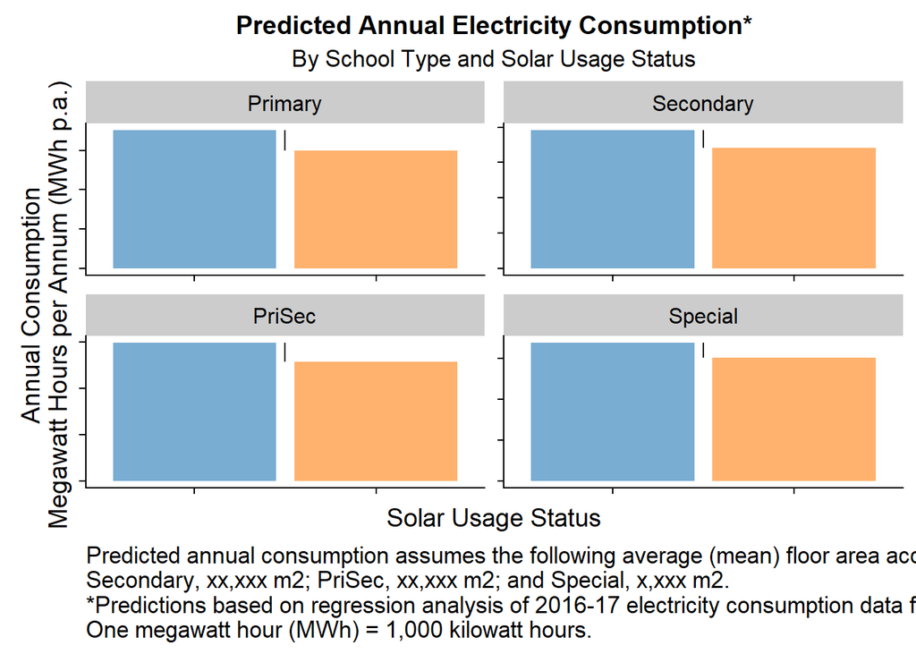

```r
df.2.pred%>%
  dplyr::select(-2) %>%
  mutate(Solar = recode_factor(Solar,`0`= "NoSolar",`1`="Solar"))%>%
  group_by(Type, Solar)%>%
  summarise(pred.fit=round(mean(fit.fit/1000),0))%>%
  mutate(End=lag(pred.fit),
         Diff=End-pred.fit,
         Pct=paste(round(Diff/End*100,0),"%"),
         xpos=1:n()-0.5)%>%
  ggplot(aes(x=Solar,y=pred.fit,fill=Solar))+
  geom_col(position="dodge", alpha=0.6)+
  facet_wrap(~Type,scales="free") +
  # hide figures if showing plot publicly
  # stat_summary(fun.y = 'mean',
  #              aes(label=scales::comma(..y..)), geom="text",
  #              vjust=1.5)+
  geom_segment(aes(x=xpos,y=End,xend=xpos,yend=pred.fit)) +
  # hide segment figures if showing plot publicly
  # geom_text(aes(x=xpos,y=End-Diff/2,label=Pct),hjust=-0.2,size=4)+
  scale_y_continuous(label=scales::comma)+
  scale_fill_tableau()+
  labs(title="Predicted Annual Electricity Consumption*",
       subtitle="By School Type and Solar Usage Status",
       y="Annual Consumption\nMegawatt Hours per Annum (MWh p.a.)",
       x="Solar Usage Status",
       caption="Predicted annual consumption assumes the following average (mean) floor area according to school type: Primary, x,xxx m2; \nSecondary, xx,xxx m2; PriSec, xx,xxx m2; and Special, x,xxx m2.\n*Predictions based on regression analysis of 2016-17 electricity consumption data for 1,xxx schools.\nOne megawatt hour (MWh) = 1,000 kilowatt hours.")+
  theme(text=element_text(size=14),
        plot.subtitle = element_text(hjust=0.5),
        plot.caption = element_text(hjust=0),
        legend.position=0)  + # hide numbers if showing publicly
  theme(axis.text = element_blank())
```

#### Simple Slopes Analysis:

**Store Simple Slope Analysis output:**

```r
smpl.slp <- sim_slopes(
  lm(Elec~Area*(Type+Solar),data=tblExLang),
  pred=Area,
  modx = Type,
  mod2 = Solar,
  centered="Area",
  robust=TRUE
  #  cond.int=TRUE,
  #  confint=TRUE
)
```

**Construct table of Simple Slope Analysis:**

```r
Type <- smpl.slp$slopes[[1]][,1]
Est.NoSolar <- smpl.slp$slopes[[1]][,2]
Est.NoSolar.LB <- smpl.slp$slopes[[1]][,4]
Est.NoSolar.UB <- smpl.slp$slopes[[1]][,5]
Est.Solar <- smpl.slp$slopes[[2]][,2]
Est.Solar.LB <- smpl.slp$slopes[[2]][,4]
Est.Solar.UB <- smpl.slp$slopes[[2]][,5]

df.smpl.slp <- cbind.data.frame(
  Type,Est.NoSolar,
  Est.NoSolar.LB,
  Est.NoSolar.UB,
  Est.Solar,
  Est.Solar.LB,
  Est.Solar.UB)

# Inspect class of each column:
sapply(df.smpl.slp[1:7], class)
```

```
##           Type    Est.NoSolar Est.NoSolar.LB Est.NoSolar.UB      Est.Solar
##       "factor"       "factor"       "factor"       "factor"       "factor"
##   Est.Solar.LB   Est.Solar.UB
##       "factor"       "factor"
```

All columns are currently a factor. Convert 2nd column onwards into numeric, round to 2 decimal places:

```r
for(i in 2:ncol(df.smpl.slp))
  {
  df.smpl.slp[,i] <- round(
    as.double(
      # convert factors to character before turning to numeric
      as.character(df.smpl.slp[,i])),2)
  }


# Re-inspect class of each column:
sapply(df.smpl.slp[1:7], class)
```

```
##           Type    Est.NoSolar Est.NoSolar.LB Est.NoSolar.UB      Est.Solar
##       "factor"      "numeric"      "numeric"      "numeric"      "numeric"
##   Est.Solar.LB   Est.Solar.UB
##      "numeric"      "numeric"
```

Directly compare Estimated Average Rate of consumption per square metre (kWh/m2) across School Type and Solar Usage:

```r
df.smpl.slp%>%
  dplyr::select(c(1:2,5))%>%
  # sort highest to lowest kWh/m2
  arrange(-Est.NoSolar)%>%
  mutate(Diff=Est.Solar-Est.NoSolar,
         Pct=paste(round(Diff/Est.NoSolar,3)*100,"%"))
```

#### Produce Visual Representation of Model f3.1.1

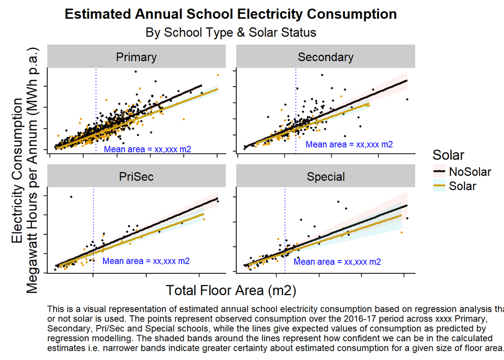

```r
# Combine original dataframe with predicted values generated by Model f3.1.1
f3.1.1_pred_3 <-cbind(tblExLang,
  predict(f3.1.1, # f3.1.1 is lm_robust object
  newdata=tblExLang,se.fit=T,interval="confidence"))

# Save Mean Floor Area by School Type:
MeanM2 <- f3.1.1_pred_3%>%
  group_by(Type)%>%
  summarise(MnM2=mean(Area),
            MinY=min(fit.fit/1000))

# geom_text x and y coordinate multipliers:
xcmult <- 1.15
ycmult <- 1.8

# Produce plot using above objects:
f3.1.1_pred_3%>%
  mutate(Solar=recode_factor(Solar,`0`="NoSolar",`1`="Solar"))%>%
  ggplot(aes(x=Area,y=Elec/1000,colour=Solar))+
  geom_point(size=0.8)+
  geom_smooth(aes(x=Area,y=fit.fit/1000),
              method="lm",
              fullrange=F,
              se=F)+
  geom_ribbon(aes(ymin=fit.lwr/1000,ymax=fit.upr/1000,fill=Solar),
              alpha=0.1,
              colour=NA)+
  scale_x_continuous(label=scales::comma)+
  scale_y_continuous(label=scales::comma)+
  labs(title="Estimated Annual School Electricity Consumption",
       subtitle="By School Type & Solar Status",
       y="Electricity Consumption\nMegawatt Hours per Annum (MWh p.a.)",
       x="Total Floor Area (m2)",
       caption="This is a visual representation of estimated annual school electricity consumption based on regression analysis that considers floor area, school type, and whether\nor not solar is used. The points represent observed consumption over the 2016-17 period across xxxx Primary,\nSecondary, Pri/Sec and Special schools, while the lines give expected values of consumption as predicted by\nregression modelling. The shaded bands around the lines represent how confident we can be in the calculated\nestimates i.e. narrower bands indicate greater certainty about estimated consumption for a given size of floor area.")+
  facet_wrap(~Type,scales="free")+
  geom_vline(data=MeanM2,aes(group=Type,xintercept=MnM2),
             linetype="dotted",
             color="blue")+
  geom_text(data=MeanM2,
            aes(x=MnM2*xcmult,
                y=MinY*ycmult,
                # hide numbers if showing plot publicly:
                # label=paste("Mean area =",
                #         scales::comma(round(MnM2,0)),"m2")

                label=paste("Mean area = xx,xxx m2")),
            inherit.aes = F,
            colour="blue",
            size=3,
            hjust=-0.01)+
  scale_color_colorblind()+
  theme(text=element_text(size=14),
        plot.subtitle = element_text(hjust=0.5),
        plot.caption = element_text(hjust=0.0, size=9)
        #        axis.text = element_text(size=11),
        #        axis.title = element_text(size=11)
  ) +
  # hide axis numbers if showing publicly
  theme(axis.text = element_blank())
```

## Ridge Regression

Ridge Regression is a technique for analysing multiple regression data impacted by multicollinearity. When multicollinearity occurs, ordinary least squares (OLS) estimates are unbiased, but their variances are large, so they may be far from the true value. Coefficients for correlated features/variables become over-inflated and can also fluctuate significantly (and even change sign). One consequence of these large fluctuations in the coefficient terms is overfitting, which means we have high variance. However by adding a degree of bias to the regression estimates, we can sometimes find a model that has a lower mean squared error (MSE) than an unbiased OLS model (the bias-variance trade-off).

Ridge regression uses a shrinkage (hyper) parameter (or ‘ridge constant’), typically called lambda ($\lambda$), to add some bias to the coefficient estimates. A $\lambda$ = 0 corresponds to the original OLS estimator. The larger the value of $\lambda$, the more the coefficient shrinks towards zero. In principal, with the right choice of $\lambda$, we can get an estimator with a better (smaller) mean squared error. The estimate is not unbiased, but what we gain in bias we make up for in smaller variance.

The assumptions of ridge regression are the same as OLS e.g. linearity, independence of residuals, and equal variances. However, the assumption of normality of residuals is not required.

**Note:** the ‘ridge’ in ridge regression refers to the diagonal of ones (1s) in the correlation matrix of the predictor variables, which can be likened to a ridge. Ridge regression proceeds by adding a degree of bias ($\lambda$) to this so-called ridge.

### Create Ridge Model using the `MASS::lm.ridge()` function

**Objective:** find the value of lambda that minimises the Mean Square Error (i.e. by minimising the Residual Sum of Squares). Use the `MASS::lm.ridge()` function to find the value optimal value of lambda. Since we don’t know what the value of lambda should be, try running a sequence of values, and look through that series of values to find the best one.

#### Create Estimator

```r
# 1) Create sequence of lambda:
     lmda.seq1 <- 10^seq(-2,1,length=100)

# 2) Fit model using lambda sequence:
     f2.1_r1 <- lm.ridge(Elec~Area.c*(Type+Solar)+Geography,
                    data=tblExLang,lambda = lmda.seq1)

# 3) Store results of model as a data.frame using broom::tidy()
     f2.1_r1_td <- tidy(f2.1_r1)
```

#### Produce Trace Plot of Lambda against Coefficient Values

A trace plot is a visualisation of coefficient values as a function of shrinkage parameter (lambda).

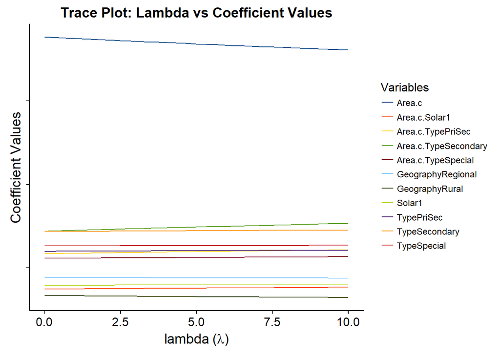

```r
ggplot(data=f2.1_r1_td,
       aes(x=lambda,y=estimate,colour=term))+
  geom_line()+
  labs(title="Trace Plot: Lambda vs Coefficient Values",
       y="Coefficient Values",
       x=expression("lambda"~"("*lambda*")"))+
  guides(color=guide_legend(title="Variables"))+
  scale_color_calc()+
  # hide numbers if showing publicly
  theme(axis.text.y = element_blank(),
        legend.text = element_text(size=9),
        legend.title = element_text(size = 12))
```

Note the relative stability of coefficients for values of lambda between 0 and 10. However as lambda approaches infinity the value of the coefficients converge toward zero. This is demonstrated by the following trace plot using large values of lambda:

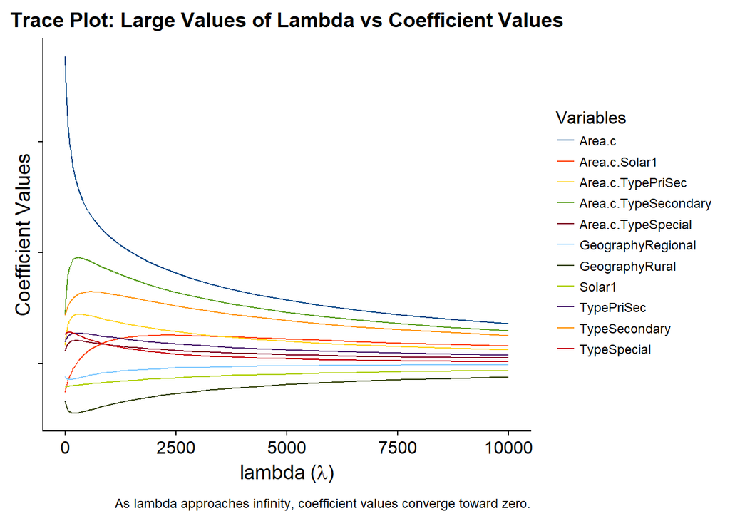

```r
# Produce sequence with large values of lambda:
  lmda.seq1.1 <- 10^seq(-2,4,length=100)

# Fit model using lambda sequence:
  f2.1_r1.1 <- lm.ridge(Elec~Area.c*(Type+Solar)+Geography,
                    data=tblExLang,lambda = lmda.seq1.1)

# Store results of model as a data.frame:
  f2.1_r1.1_td <- tidy(f2.1_r1.1)

# Produce Plot:
  ggplot(data= f2.1_r1.1_td,
         aes(x=lambda, y=estimate,colour=term))+
    geom_line()+
      labs(title="Trace Plot: Large Values of Lambda vs Coefficient Values",
           y="Coefficient Values",
           x=expression("lambda"~"("*lambda*")"),
           caption="As lambda approaches infinity, coefficient values converge toward zero.")+
  guides(color=guide_legend(title="Variables"))+
  scale_color_calc()+
  # hide numbers if showing publicly
  theme(axis.text.y = element_blank(),
        legend.text = element_text(size=9),
        legend.title = element_text(size = 12),
        plot.caption = element_text(size = 9))
```

#### Find the Optimal Value of Lambda that Minimises the Mean Squared Error of the Model

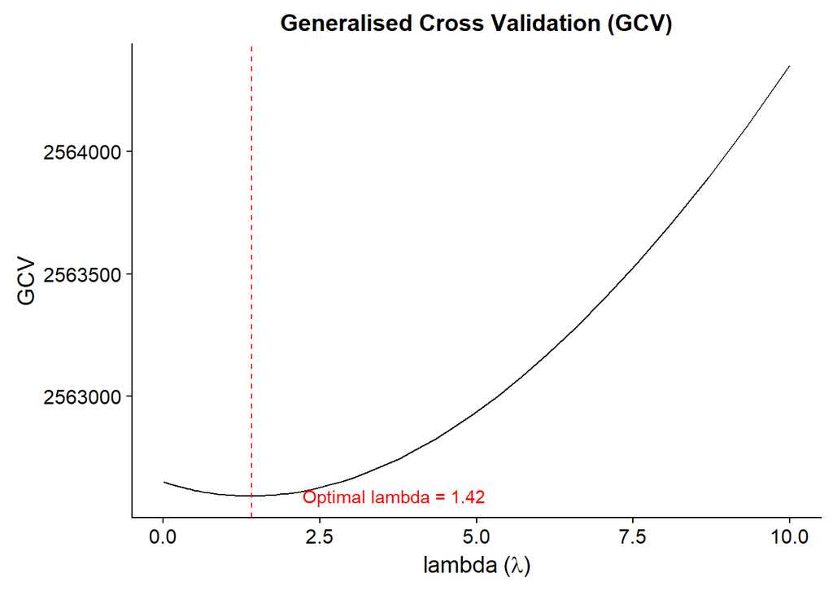

```r
GCV_min <- min(f2.1_r1$GCV)
lambda_opt <- f2.1_r1$lambda[which.min(f2.1_r1$GCV)]

# Plot using ggplot:
ggplot(data=f2.1_r1_td,
       aes(x=lambda,y=GCV))+
  geom_line()+
  geom_vline(xintercept = lambda_opt, colour="red",lty="dashed")+
  labs(title = "Generalised Cross Validation (GCV)",
       x=expression("lambda"~"("*lambda*")")
       )+
  annotate(geom="text",x=lambda_opt*2.6, y=min(GCV_min),
           label=paste("Optimal lambda =",round(lambda_opt,2)),
           colour="red")
```

#### Run the Ridge Model Again Using $\lambda$ = $\lambda$<sub>optimal</sub>

##### Run the ridge regression model again using optimal value of $\lambda$

```r
# Run the model using optimal lambda:
f2.1_r1.2 <- lm.ridge(Elec~Area.c*(Type+Solar)+Geography,
                    data=tblExLang,lambda = lambda_opt)
# Store results:
f2.1_r1.2_td <- tidy(f2.1_r1.2)
```

##### Compare Coefficients of Ridge model vs OLS model:

```r
# Compare coefficients of ridge vs ols:
cbind("ridge" = round(coef(f2.1_r1.2),2),"ols" = round(coef(f2.1),2))
```

##### Compare Mean Square Error of Ridge vs OLS

**Note:** No easy way to extract MSE from object of class “ridgelm” (such as from `MASS::lm.ridge()`). Therefore will need to do this by hand using matrix computation.

```r
#### Step 1: Extract and set up relevant data matrices

  # Extract relevant variables from original dataset tblExLang:
    dataRidge <- tblExLang%>%
        dplyr::select(Elec,Area.c,Type,Solar,Geography)

  # Store the f2.1 specification as an object of class = "formula":
    f1 <- as.formula(Elec~Area.c*(Type+Solar)+Geography)

  # Vector of Response Variable (y) values:
    y1 <- dataRidge$Elec

  # Matrix of Predictor Variable (x) values:
    x1 <- model.matrix(f1,dataRidge)[,-1]  # Note: [-1] removes the first column (the intercept) from the model matrix

#### Step 2: Calculate predicted (pred.rdg) responses using the model matrix (x1) and the coefficents from the Ridge model (f2.1_r1.2)

pred.rdg <- as.matrix(cbind(const=1,x1)) %*% coef(f2.1_r1.2)  # %*% for matrix multiplication

#### Step 3: Calculate Mean Squared Error for Ridge Model
MSE.rdg <- mean((pred.rdg - y1)^2)

#### Step 4: Repeat Steps 2 and 3 for OLS model f2.1
pred.ols <- as.matrix(cbind(const=1,x1)) %*% coef(f2.1)
MSE.ols <- mean((pred.ols - y1)^2)

  # Check that calculated MSE.ols = MSE for original lm() object
  cbind(MSE.ols,mean(f2.1$residuals^2))
```

```
##         MSE.ols
## [1,] 3631489496 3631489496
```

```r
#### Step 5: Compare MSE.rdg with MSE.ols

list(Compare_MSE = cbind("MSE.rdg" = MSE.rdg, "MSE.ols" = MSE.ols),
     `MSE.rdg_<_MSE.ols?` = MSE.rdg < MSE.ols,
     Percent_diff = scales::percent(MSE.rdg/MSE.ols-1)
     )
```

```
## $Compare_MSE
##         MSE.rdg    MSE.ols
## [1,] 3631574907 3631489496
##
## $`MSE.rdg_<_MSE.ols?`
## [1] FALSE
##
## $Percent_diff
## [1] "0.00235%"
```

##### Compare R<sup>2</sup> of Ridge and OLS

```r
# R-squared for Ridge
sst <- sum((y1 - mean(y1))^2)
sse.rdg <- sum((pred.rdg - y1)^2)
rsq.rdg <-  1 - sse.rdg/sst

# R-squared for OLS
sse.ols<- sum((pred.ols - y1)^2)
rsq.ols <-  1 - sse.ols/sst

# Compare R-Squared
cbind("RSQ.rdg" = rsq.rdg,
      "RSQ.ols" = rsq.ols)
```

```
##        RSQ.rdg   RSQ.ols
## [1,] 0.8472165 0.8472201
```

Coefficients of the ridge regression are similar to the OLS model. The first trace plot also showed that the coefficients are fairly stable against increasing bias, and it would take a lot of bias (i.e. high values of $\lambda$) to create unstable OLS estimates. Therefore we can conclude that the multicollinearity present in the OLS model is not problematic. Furthermore, the Ridge model did not improve the OLS model as shown by the neglibible difference in MSE. This outcome, combined with practically the same R<sup>2</sup> $\approx$ 0.85 implies that the original least squares model already had sound predictive ability.

### Ridge Regression with `glmnet` Package

#### Load `glmnet` and Select Variables

```r
# Load glmnet Package
library(glmnet)

# Select relevant variables from the original tbl, save as new tbl:
dataRidge <- tblExLang%>%
  dplyr::select(Elec,Area.c,Type,Solar,Geography)
```

#### Create Formula, Vector of Response Variable (y) Values, and Matrix of Predictor Variable (x) Values

```r
# Formula:
f1 <- as.formula(Elec~Area.c*(Type+Solar)+Geography)

# Vector of Response Variable (y) values:
y1 <- dataRidge$Elec

# Matrix of Predictor Variable (x) values:
x1 <- model.matrix(f1,dataRidge)[,-1]  # Note: [-1] removes the first column (the intercept) from the model matrix
```

**Note:** `model.matrix()` creates a design matrix and transforms categorical variable to dummy variables.

#### Commence Cross-Validation

Cross Validation is used to assess the predictive performance of the models and and to judge how they perform outside the sample to a new data set also known as ‘test’ data.

The motivation for cross-validation is that when we fit a model, we are fitting it to a ‘training’ dataset. Without cross-validation we only have information on how does our model perform to our *in-sample* data. Ideally we would like to see how the model performs in terms of prediction accuracy when we have a new data.

##### Create Training and Testing Datasets

Here, we will perform a random 50/50 split of the data into two separate training and testing datasets.

```r
# Step 1. Create a 'random selector vector' for randomly choosing half the predictor variable values from the model matrix (x1):

train <- sample(1:nrow(x1),         # out of n rows from the model matrix...
                nrow(x1)/2)         # randomly select n/2 rows.


# Step 2. Split data into training and test sets
x1.train <- x1[train,]
x1.test <- x1[-train,]
y1.train <- y1[train]
y1.test <- y1[-train]

# Note: see [6.6: Ridge Regression and the Lasso](http://www.science.smith.edu/~jcrouser/SDS293/labs/lab10-r.html#6.6.1-Ridge-Regression) for alternative method of splitting data using dplyr::sample_frac()
```

#### Generate Sequence of Lambda ($\lambda$)

Ridge regression involves tuning a hyperparameter, $\lambda$. glmnet() will generate default values for you. Alternatively, it is common practice to define your own with a `lambda =` argument:

```r
# Generate a descending sequence of 100 lambda values:
lambda_seq <- 10^seq(3,-3,length=100)
```

#### Call ridge regression based on training dataset, using the descending lambda sequence

Use `glmnet::glmnet()`, with alpha = 0 to conduct ridge regression.

```r
# Call ridge regression based on training dataset, using the descending lambda sequence:
rdg.train <- glmnet(x=x1.train,y=y1.train,alpha=0,lambda = lambda_seq)

# Confirm number of models created:
dim(coef(rdg.train))
```

```
## [1]  12 100
```

100 models with different lambda values created, each with 12 coefficients (including the intercept).

[figure not shown]

```r
rdg.train_tidy <- broom::tidy(rdg.train)

ggplot(data=rdg.train_tidy,
       aes(x=lambda, y=estimate, colour=term)) +
  geom_line()+
  labs(title="Trace Plot: Log Lambda vs Coefficient Values",
       y="Coefficient Values",
       x=expression("log("*lambda*")"))+
  guides(color=guide_legend(title="Variables"))+
  scale_color_calc()+
  # hide numbers if showing publicly
  theme(axis.text.y = element_blank(),
        legend.text = element_text(size=9),
        legend.title = element_text(size = 12))
```

#### Perform k-fold Cross-Validation Ridge Regression using `glmnet::cv.glmnet()` Function

Lambda ($\lambda$) is a tuning parameter that helps to control our model from over-fitting to the training data. However, to identify the optimal $\lambda$ value we need to perform cross-validation. `cv.glmnet` provides a built-in option to perform *k*-fold cross-validation, and by default, performs 10-fold cross-validation.

*k*-fold cross-validation involves randomly dividing the data into *k* groups (aka folds) of approximately equal size. The first fold is treated as a validation set, and the statistical method is fit on the remaining data. The mean squared error, *MSE*<sub>1</sub> is then computed on the observations in the held-out fold. This procedure is repeated *k* times; each time, a different group of observations is treated as the validation set. This process results in *k* estimates of the test error, *MSE*<sub>1</sub>,*MSE*<sub>2</sub>,…*MSE*<sub>*k*</sub>. Thus, the *k*-fold cross-validation (CV) estimate is computed by averaging these values:

$$CV_{(k)} = \frac{1}{k}\displaystyle\sum_{i=1}^{k}MSE_{i}$$

Again, the optimal log($\lambda$) is obtained using cross-validation by minimising the mean squared error of a prediction:

```r
# Run k-fold cross-validation regression (note that k = 10 by default)
rdg.cv <- cv.glmnet(x1.train, y1.train, alpha=0)

# Extract optimal (log)lambda
opt_lambda <- rdg.cv$lambda.min

( loglambda.opt <- log(opt_lambda)  )
```

```
## [1] 9.674389
```

#### Plot Results using `glmnet::plot.cv.glmnet()` Function

This will produce a **cross-validation curve** (red dotted line), as well upper and lower standard deviation curves along the $\lambda$ sequence (error bars). The figures along the top are simply the number of (non-zero) coefficients (excluding the intercept) for each value of $\lambda$.

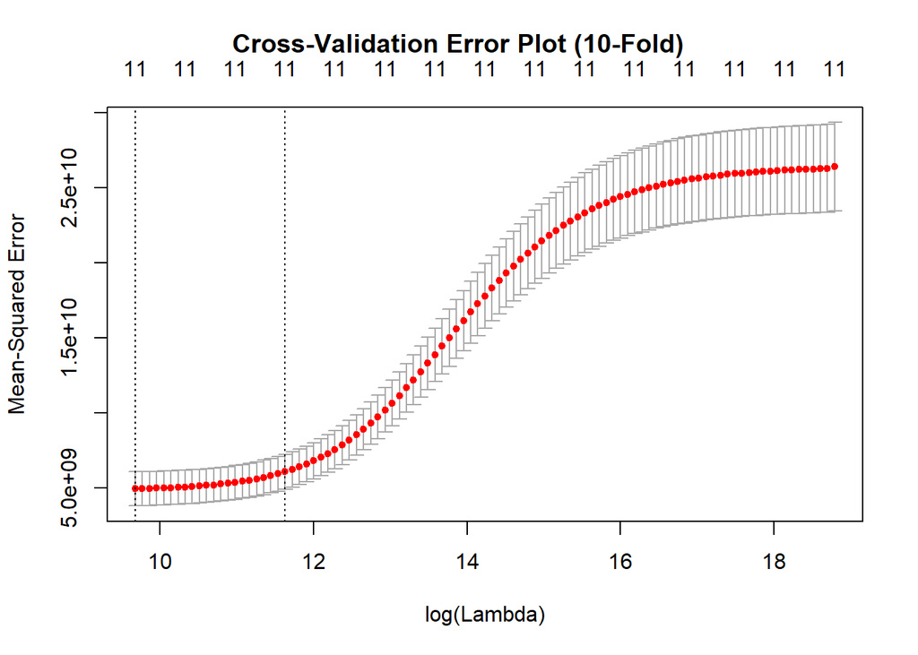

```r
plot.cv.glmnet(rdg.cv)
title(main="Cross-Validation Error Plot (10-Fold)",outer=TRUE, line=-2)
```

The vertical dotted lines reflect two common choices for values of $\lambda$:

- The smallest value is log($\lambda$<sub>min</sub>), which gives minimum mean cross-validated error; this is saved as `loglambda.opt`.
- The other value is log($\lambda$<sub>1se</sub>), and is the largest value that is within one standard error of log($\lambda$<sub>min</sub>).

In this context we’ll continue with the ridge regression modelling by using log($\lambda$<sub>min</sub>).

**Side note:** Having two $\lambda$ values is generally used in the context of *LASSO* (Least Absolute Shrinkage and Selection Operator) regression. In ridge regression, while the coefficients *converge* toward zero as $\lambda \to \infty$, they never reach zero. However, in LASSO regression, coefficients *do* fall to zero given high enough values of $\lambda$, which is why lasso can be used as a method of parameter selection.

One reason for using $\lambda$<sub>1se</sub> in LASSO regression is to hedge against overfitting by selecting a larger $\lambda$ than the minimum. The error at $\lambda$<sub>min</sub> is the average of the errors over the *k* folds and hence this *estimate* of the error is uncertain. $\lambda$<sub>1se</sub> represents the value that results in a simpler model (i.e. less parameters), but which has an error within 1 standard error of the best model. In othe words, using $\lambda$<sub>1se</sub> results in a slightly simpler model, but one that cannot be distinguished from the best model in terms of error (given the uncertainty in the *k*-fold CV error estimate of the best model).

#### Generate New Ridge Predictions Against Test Data using Optimal $\lambda$

Apply the original Ridge training model (`rdg.train`) against new predictor (x) values saved in the *test* datasets while using optimal lambda

```r
# Apply ridge model using test data and optimal lambda
rdg.pred <- predict(rdg.train, newx=x1.test, s=opt_lambda)
```

#### Generate Predictions against Test Data using parameters reflecting OLS

**Note:** In order for glmnet() to yield the exact least squares coefficients when $\lambda$=0 , we use the argument `exact=T` when calling the predict() function. Otherwise, `predict()` will interpolate over the grid of $\lambda$ values used in fitting the glmnet() model, yielding approximate results. Even when we use `exact = T`, there remains a slight discrepancy between `glmnet()` and `lm` output due to numerical approximation on the part of glmnet(). Furthermore, when using `exact = T`, we are forced to supply the original `x=` and `y=` arguments(in this case x=x1.train and y=y1.train) to safely rerun `glmnet`.

```r
# Generate predictions that reflect OLS regression:
ols.pred <- predict(rdg.train, x=x1.train,  y=y1.train,
                   newx=x1.test, s=0,exact=T)
```

#### Compare Ridge and OLS Coefficients Calculated Against Test Data

```r
# Coefficients, Ridge vs OLS
cbind(
  predict(rdg.train, newx=x1.test, s=opt_lambda, type="coefficients"),
  predict(rdg.train, x=x1.train,  y=y1.train, newx=x1.test, s=0,exact=T, type = "coefficients")
  )
```

#### Compare Mean Square Error of Ridge Regression and OLS Regression

```r
# Store MSE for Ridge and OLS
MSE.rdg <- mean((rdg.pred - y1.test)^2 )
MSE.ols <- mean((ols.pred - y1.test)^2)

# Compare MSE
list(
  MSE_Compare = cbind("MSE Ridge" = MSE.rdg,"MSE OLS" = MSE.ols),
  `MSE.rdg_<_MSE.ols?` = MSE.rdg < MSE.ols,
  `Percent_Diff` = scales::percent(round((MSE.rdg/MSE.ols - 1),4))
  )
```

```
## $MSE_Compare
##       MSE Ridge    MSE OLS
## [1,] 2898492008 2896908115
##
## $`MSE.rdg_<_MSE.ols?`
## [1] FALSE
##
## $Percent_Diff
## [1] "0.05%"
```

#### Compare R<sup>2</sup> for both Ridge and OLS regression estimates

```r
# Sum of Squares Total and Error - Ridge
sst <- sum((y1.test - mean(y1.test))^2)
sse.rdg <- sum((rdg.pred - y1.test)^2)

# R-squared - Ridge
rsq.rdg <- 1 - sse.rdg/sst

# Sum of Squares Total and Error - OLS
sst <- sum((y1.test - mean(y1.test))^2)
sse.ols <- sum((ols.pred - y1.test)^2)

# R-squared - OLS
rsq.ols <- 1 - sse.ols/sst

list(R_squared_Ridge = round(rsq.rdg,4),
     R_squared_OLS = round(rsq.ols,4))
```

```
## $R_squared_Ridge
## [1] 0.8632
##
## $R_squared_OLS
## [1] 0.8632
```

In many cases, Ridge regression produces more stable estimates than OLS, making it less prone to over-fitting training data. Ridge regression might, therefore, predict training data less well than OLS, but better generalise to new data. This will particularly be the case when extreme variance in the training data is high, which tends to happen when the sample size is low and/or the number of features is high relative to the number of observations. (See [Jackson, S.,2017,‘How and when: ridge regression with glmnet’](https://drsimonj.svbtle.com/ridge-regression-with-glmnet) for a full discussion)

However in this case, we have a larger number of observations (over 1,400), and a relatively small number of variables (11). This may explain why multicollinearity has thus far not proven to be problematic in the OLS model, and why it has similar prediction performance to Ridge regression.

#### Re-create and Re-fit Ridge Regression Model on *Full* Dataset, using Optimal $\lambda$

##### Create Ridge Model and Re-fit Model:

```r
# Re-Create model and re-fit using full sets x1 and y1
rdg.fit <- glmnet(x1, y1, alpha = 0, lambda = lambda_seq)

# Re-fit ridge model using optimal lambda
rdg.fit.pred <- predict(rdg.fit,type = "coefficients", s=opt_lambda)

# Predicted y-values from re-fitted model:
rdg.fit.pred_y <- predict(rdg.fit, newx = x1, s=opt_lambda)
```

##### Re-fit model using $\lambda$ = 0 (for OLS)

```r
# Re-fit OLS model using lambda = 0:
ols.fit.pred <- predict(rdg.fit, x=x1,y=y1, s=0, newx = x1, exact=T,type="coefficients")

# Predicted y-values from re-fitted model:
ols.fit.pred_y <- predict(rdg.fit, x=x1,y=y1, newx = x1, s=0, exact=T)
```

##### Compare Ridge and OLS Coefficients Calculated against Full Dataset

```r
# Ridge and OLS Coefficients Comparison:
cbind(rdg.fit.pred, ols.fit.pred)
```

##### Compare MSE<sub>Ridge</sub> with MSE<sub>OLS</sub>

```r
MSE_rdg.fit <- mean((rdg.fit.pred_y - y1)^2)
MSE_ols.fit <- mean((ols.fit.pred_y - y1)^2)

# Is MSE_rdg.full < MSE_ols.full
MSE_rdg.fit < MSE_ols.fit
```

```
## [1] FALSE
```

```r
# Percentage change in Mean Square Error:
scales::percent(MSE_rdg.fit/MSE_ols.fit - 1) # percent() function from scales package
```

```
## [1] "0.0775%"
```

```r
# Store MSE for Ridge and OLS
MSE_rdg.fit <- mean((rdg.fit.pred_y - y1)^2)
MSE_ols.fit <- mean((ols.fit.pred_y - y1)^2)

# Compare MSE
list(
  MSE_Compare = cbind("MSE Ridge"=MSE_rdg.fit, "MSE OLS"=MSE_ols.fit),
  `MSE.rdg_<_MSE.ols?` = MSE_rdg.fit < MSE_ols.fit,
  Percent_Diff = scales::percent(round((MSE_rdg.fit/MSE_ols.fit-1),4))
  )
```

```
## $MSE_Compare
##       MSE Ridge    MSE OLS
## [1,] 3634303677 3631489496
##
## $`MSE.rdg_<_MSE.ols?`
## [1] FALSE
##
## $Percent_Diff
## [1] "0.08%"
```

##### Compare R<sup>2</sup> for both Ridge and OLS regression estimates

```r
# Sum of Squares Total and Error - Ridge
sst.rdg <- sum((y1 - mean(y1))^2)
sse.rdg <- sum((rdg.fit.pred_y - y1)^2)

# R-squared - Ridge
rsq.rdg <- 1 - sse.rdg/sst.rdg

# Sum of Squares Total and Error - OLS
sst.ols <- sum((y1 - mean(y1))^2)
sse.ols <- sum((ols.fit.pred_y - y1)^2)

# R-squared - Ridge
rsq.ols <- 1 - sse.ols/sst.ols

list(R_squared_Ridge = round(rsq.rdg,4),
     R_squared_OLS = round(rsq.ols,4))
```

```
## $R_squared_Ridge
## [1] 0.8471
##
## $R_squared_OLS
## [1] 0.8472
```

##### Summarise Ridge vs OLS Modelling Results

```r
list(Ridge.Coeffs_vs_OLS.Coeffs = cbind(rdg.fit.pred, ols.fit.pred))
```

```r
list(
  MSE_Compare = cbind("MSE Ridge"=MSE_rdg.fit, "MSE OLS"=MSE_ols.fit),
  `MSE.rdg_<_MSE.ols?` = MSE_rdg.fit < MSE_ols.fit,
  Percent_Diff = scales::percent(round((MSE_rdg.fit/MSE_ols.fit-1),4)),
  R_Squared_Compare = cbind("R-squared_Ridge" = round(rsq.rdg,4),"R-squared_OLS" = round(rsq.ols,4))
  )
```

```
## $MSE_Compare
##       MSE Ridge    MSE OLS
## [1,] 3634303677 3631489496
##
## $`MSE.rdg_<_MSE.ols?`
## [1] FALSE
##
## $Percent_Diff
## [1] "0.08%"
##
## $R_Squared_Compare
##      R-squared_Ridge R-squared_OLS
## [1,]          0.8471        0.8472
```

As expected, Ridge regression delivered negligible (if any) benefit over the original OLS model. This again implies that the original OLS model was not impacted by multicollinearity and has sound predictive performance.